# Impact Analysis of Severe Weather Events on Public Health and Economic in the United States

Zhaohe Su

Friday, April 24, 2015

# Synopsis

Storms and other severe weather events can cause both public health and economic problems for communities and municipalities. Many severe events can result in fatalities, injuries, and property damage, and preventing such outcomes to the extent possible is a key concern.  
This is a reproducible research document to explore the U.S. National Oceanic and Atmospheric Administration’s (NOAA) Storm Database to try to find out the impact of severe weather events on public health and economic in the United States.  
The events in the database start in the year 1950 and end in November 2011. In the earlier years of the database there are generally fewer events recorded, most likely due to a lack of good records. More recent years should be considered more complete.  
The data analysis addresses the following questions: 1. Across the United States, which types of events (as indicated in the EVTYPE variable) are most harmful with respect to population health? 2. Across the United States, which types of events have the greatest economic consequences?

# Load Requied packages

```r
library(dplyr, quietly = TRUE)
```

# Data Processing

## Download and Read Data

```r
if ( !file.exists("data")) {
    dir.create("data")
}
if ( !file.exists("./data/StormData.csv.bz2")) {
    url <- "https://d396qusza40orc.cloudfront.net/repdata%2Fdata%2FStormData.csv.bz2"
    download.file(url, "./data/StormData.csv.bz2")
}
if ( !( "stormData" %in% ls() ) ) {
    stormData <- read.csv( bzfile("./data/StormData.csv.bz2"), sep="," )
}
dim(stormData)
```

```
## [1] 692288     37
```

```r
colnames(stormData)
```

```
##  [1] "STATE__"    "BGN_DATE"   "BGN_TIME"   "TIME_ZONE"  "COUNTY"
##  [6] "COUNTYNAME" "STATE"      "EVTYPE"     "BGN_RANGE"  "BGN_AZI"
## [11] "BGN_LOCATI" "END_DATE"   "END_TIME"   "COUNTY_END" "COUNTYENDN"
## [16] "END_RANGE"  "END_AZI"    "END_LOCATI" "LENGTH"     "WIDTH"
## [21] "F"          "MAG"        "FATALITIES" "INJURIES"   "PROPDMG"
## [26] "PROPDMGEXP" "CROPDMG"    "CROPDMGEXP" "WFO"        "STATEOFFIC"
## [31] "ZONENAMES"  "LATITUDE"   "LONGITUDE"  "LATITUDE_E" "LONGITUDE_"
## [36] "REMARKS"    "REFNUM"
```

```r
head(stormData, n=3)
```

```
##   STATE__          BGN_DATE BGN_TIME TIME_ZONE COUNTY COUNTYNAME STATE
## 1    1.00 4/18/1950 0:00:00     0130       CST  97.00     MOBILE    AL
## 2    1.00 4/18/1950 0:00:00     0145       CST   3.00    BALDWIN    AL
## 3    1.00 2/20/1951 0:00:00     1600       CST  57.00    FAYETTE    AL
##    EVTYPE BGN_RANGE BGN_AZI BGN_LOCATI END_DATE END_TIME COUNTY_END
## 1 TORNADO      0.00                                            0.00
## 2 TORNADO      0.00                                            0.00
## 3 TORNADO      0.00                                            0.00
##   COUNTYENDN END_RANGE END_AZI END_LOCATI LENGTH  WIDTH F  MAG FATALITIES
## 1                 0.00                     14.00 100.00 3 0.00       0.00
## 2                 0.00                      2.00 150.00 2 0.00       0.00
## 3                 0.00                      0.10 123.00 2 0.00       0.00
##   INJURIES PROPDMG PROPDMGEXP CROPDMG CROPDMGEXP WFO STATEOFFIC ZONENAMES
## 1    15.00   25.00          K    0.00
## 2     0.00    2.50          K    0.00
## 3     2.00   25.00          K    0.00
##   LATITUDE LONGITUDE LATITUDE_E LONGITUDE_ REMARKS REFNUM
## 1  3040.00   8812.00    3051.00    8806.00           1.00
## 2  3042.00   8755.00       0.00       0.00           2.00
## 3  3340.00   8742.00       0.00       0.00           3.00
```

## Subset and Clean Data

We choose the following columns to do the analysis:  
- EVTYPE: the type of event  
- FATALITIES: number of fatalities  
- INJURIES: number of injuries  
- PROPDMG: damage to properties in USD  
- PROPDMGEXP: magnitude for properties damage (K for thousands, M for millions, B for billions)  
- CROPDMG: damage to crops in USD  
- CROPDMGEXP: magnitude for crops damage (K for thousands, M for millions, B for billions)

```r
subStormData <- stormData %>%
                select( EVTYPE, FATALITIES, INJURIES, PROPDMG, PROPDMGEXP, CROPDMG, CROPDMGEXP )
```

The valid values in magnitude fields are: “”(empty for one), K(for thousands), M(for millions) and B(for billions). So we clean the data where the magnitude fields contain invalid value, convert the invalid value to 1, which means that it has a magnitude of 1( 10 to the power 0 ).

```r
subStormData$PROPDMGEXP <- ifelse( subStormData$PROPDMGEXP %in% c( "H", "K", "M", "B", "h", "k", "m", "b"),
                                   as.character(subStormData$PROPDMGEXP),
                                   "1" )
subStormData$PROPDMGEXP <- sub("^H$", "100", subStormData$PROPDMGEXP, ignore.case=TRUE )
subStormData$PROPDMGEXP <- sub("^K$", "1000", subStormData$PROPDMGEXP, ignore.case=TRUE )
subStormData$PROPDMGEXP <- sub("^M$", "1000000", subStormData$PROPDMGEXP, ignore.case=TRUE )
subStormData$PROPDMGEXP <- sub("^B$", "1000000000", subStormData$PROPDMGEXP, ignore.case=TRUE )

subStormData$CROPDMGEXP <- ifelse( subStormData$CROPDMGEXP %in% c( "H", "K", "M", "B", "h", "k", "m", "b"),
                                   as.character(subStormData$CROPDMGEXP),
                                   "1" )
subStormData$CROPDMGEXP <- sub("^H$", "100", subStormData$CROPDMGEXP, ignore.case=TRUE )
subStormData$CROPDMGEXP <- sub("^K$", "1000", subStormData$CROPDMGEXP, ignore.case=TRUE )
subStormData$CROPDMGEXP <- sub("^M$", "1000000", subStormData$CROPDMGEXP, ignore.case=TRUE )
subStormData$CROPDMGEXP <- sub("^B$", "1000000000", subStormData$CROPDMGEXP, ignore.case=TRUE )
```

# Results

## Top 10 Events causing the most fatalities

```r
subStormData$FATALITIES <- as.numeric(subStormData$FATALITIES)
mostFatalities <- subStormData %>%
                  select( EVTYPE, FATALITIES ) %>%
                  filter( FATALITIES > 0 ) %>%
                  group_by( EVTYPE ) %>%
                  summarise( TOTAL_FATALITIES = sum(FATALITIES) ) %>%
                  arrange( desc(TOTAL_FATALITIES) ) %>%
                  head(10)
mostFatalities
```

```
## Source: local data frame [10 x 2]
##
##                EVTYPE TOTAL_FATALITIES
## 1           TSTM WIND       3662292239
## 2                HAIL       3489157210
## 3             TORNADO        950774290
## 4         FLASH FLOOD        529405439
## 5  THUNDERSTORM WINDS        401908428
## 6           LIGHTNING        192050763
## 7               FLOOD        184876675
## 8          HEAVY SNOW        163378571
## 9           HIGH WIND        143340277
## 10         HEAVY RAIN         92661638
```

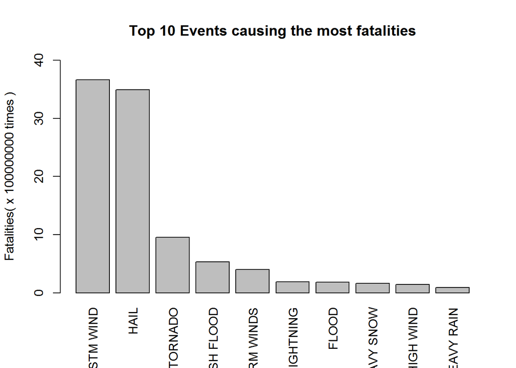

```r
barplot(mostFatalities$TOTAL_FATALITIES/100000000,
        names.arg=mostFatalities$EVTYPE,
        ylab="Fatalities( x 100000000 times )",
        ylim=c(0,40),
        las=3,
        main="Top 10 Events causing the most fatalities")
```

## Top 10 Events causing the most injuries

```r
subStormData$INJURIES <- as.numeric(subStormData$INJURIES)
mostInjuries <- subStormData %>%
                  select( EVTYPE, INJURIES ) %>%
                  filter( INJURIES > 0 ) %>%
                  group_by( EVTYPE ) %>%
                  summarise( TOTAL_INJURIES = sum(INJURIES) ) %>%
                  arrange( desc(TOTAL_INJURIES) ) %>%
                  head(10)
mostInjuries
```

```
## Source: local data frame [10 x 2]
##
##                EVTYPE TOTAL_INJURIES
## 1           TSTM WIND     3592076894
## 2                HAIL     3421724779
## 3             TORNADO      934260411
## 4         FLASH FLOOD      519156191
## 5  THUNDERSTORM WINDS      394216207
## 6           LIGHTNING      188752999
## 7               FLOOD      181296729
## 8          HEAVY SNOW      160234725
## 9           HIGH WIND      140622005
## 10         HEAVY RAIN       90872826
```

[figure not shown]

```r
barplot(mostInjuries$TOTAL_INJURIES/1000000000,
        names.arg=mostInjuries$EVTYPE,
        ylab="Injuries( x 100000000 times )",
        ylim=c(0,4),
        las=3,
        main="Top 10 Events causing the most injuries")
```

## Top 10 Events having the greatest economic consequences

```r
subStormData$PROPDMG <- as.numeric(subStormData$PROPDMG)
subStormData$PROPDMGEXP <- as.numeric(subStormData$PROPDMGEXP)
subStormData$CROPDMG <- as.numeric(subStormData$CROPDMG)
subStormData$CROPDMGEXP <- as.numeric(subStormData$CROPDMGEXP)
mostProperties <- subStormData %>%
                  select( EVTYPE, PROPDMG, PROPDMGEXP, CROPDMG, CROPDMGEXP ) %>%
                  group_by( EVTYPE ) %>%
                  summarise( TOTAL_PROPERTIES = sum( PROPDMG * PROPDMGEXP + CROPDMG * CROPDMGEXP ) ) %>%
                  arrange( desc(TOTAL_PROPERTIES) ) %>%
                  head(10)
mostProperties
```

```
## Source: local data frame [10 x 2]
##
##               EVTYPE TOTAL_PROPERTIES
## 1  HURRICANE/TYPHOON     7.793217e+13
## 2            TORNADO     7.250598e+13
## 3          HURRICANE     3.973277e+13
## 4        RIVER FLOOD     3.830355e+13
## 5     HURRICANE OPAL     3.807517e+13
## 6        FLASH FLOOD     3.576281e+13
## 7              FLOOD     3.359544e+13
## 8          HIGH WIND     2.235290e+13
## 9       WINTER STORM     2.099765e+13
## 10    TROPICAL STORM     2.054909e+13
```

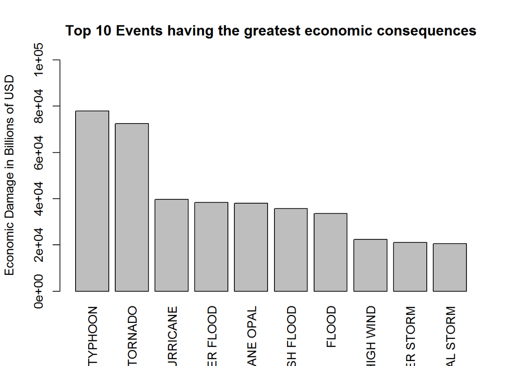

```r
barplot(mostProperties$TOTAL_PROPERTIES/1000000000,
        names.arg=mostProperties$EVTYPE,
        ylim=c(0,100000),
        las=3,
        ylab="Economic Damage in Billions of USD",
        main="Top 10 Events having the greatest economic consequences")
```